# Binomial distribution (The Math Sorcerer)

Luis Cárceles

## Introduction

The [Math Sorcerer Youbube video playlists](https://www.youtube.com/playlist?list=PLO1y6V1SXjjPGvAwihi1vp_kqxwqUd0cI)

See also the information about [binomial distribution and R Studio](https://www.geeksforgeeks.org/binomial-distribution-in-r-programming/)

## Problems

### Problem 1

It turns out to be that 41% of people use their smartphone in meetings or classes. We select randomly a group of 7 people.

Which is the probability that exactly 3 of the use their smartphone in classroom or in a meeting?

```r
x1 <- dbinom(3, size=7, prob=0.41)
sprintf("The probability of exactly 3 adults use their smartphone is: %f", x1)
```

```
## [1] "The probability of exactly 3 adults use their smartphone is: 0.292299"
```

### Problem 2

Now assume that 54% of people use their smartphone in class. We select randomly a group of 5 people. Which is the probability that at least three people use their smartphone?

```r
x2 <- 1-pbinom(3-1, size=5, prob=0.54)
sprintf("The probability that at least 3 people use their smartphone: %f", x2)
```

```
## [1] "The probability that at least 3 people use their smartphone: 0.574681"
```

### Problem 3

Based on a poll, 60% of adults believe in reincarnation. Assume that 4 adults are randomly selected and find the indicated probability.

a: What is the probability that exactly 3 of the 4 adults believe in reincarnation?

```r
a<-dbinom(3, size=4, prob=0.6)
sprintf("Probability of exactly 3 of 4 adults believe in reincarnation: %f", a)
```

```
## [1] "Probability of exactly 3 of 4 adults believe in reincarnation: 0.345600"
```

b: What is the probability that all of the selected adults believe in reincarnation?

```r
b<-dbinom(4, size=4, prob=0.6)
sprintf("Probability that all of selected adults believe in reincarnation: %f", b)
```

```
## [1] "Probability that all of selected adults believe in reincarnation: 0.129600"
```

c: What is the probability that at least 3 of the selected adults believe in reincarnation?

```r
c<- 1-pbinom(2, size=4, prob=0.6)
sprintf("Probability that at least 3 of the selected believe in reincarnation: %f", c)
```

```
## [1] "Probability that at least 3 of the selected believe in reincarnation: 0.475200"
```

### Problem 4

Assume that hybridization experiments are conducted with peas having the property that for offspring, there is a 0.25 probability that a pea has green pods. Assume that the offspring peas are randomly selected in groups of 26.

a: Find the mean and the standard deviation for the numbers of peas with green pods in the groups of 26.

```r
size=26
p=0.25
q<-1-p
mean_<-size*p
sd<-sqrt(size*p*q)
sprintf("Mean: %f", mean_)
```

```
## [1] "Mean: 6.500000"
```

```r
sprintf("Standard deviation: %f", sd)
```

```
## [1] "Standard deviation: 2.207940"
```

b: Use the range rule of thumb to find the values separating results that are significantly low or significantly high

```r
minUsualValue<-mean_-2*sd
maxUsualValue<-mean_+2*sd
sprintf("Minimum Usual Value: %f", minUsualValue)
```

```
## [1] "Minimum Usual Value: 2.084120"
```

```r
sprintf("Maximum Usual Value: %f", maxUsualValue)
```

```
## [1] "Maximum Usual Value: 10.915880"
```

Any value between those values will be considered an usual value.

c: Print a graph of this binomial distribution

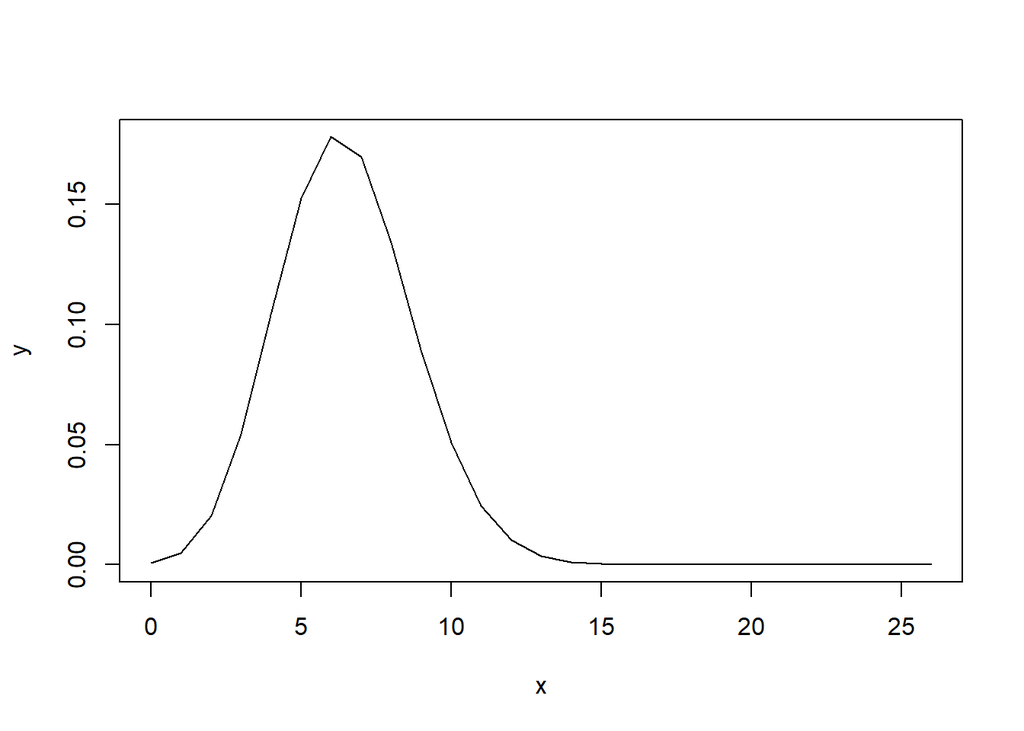

```r
x <- seq(0, 26, by = 1)
y <- dbinom(x, size = 26, prob = 0.25)
plot(x, y, type = 'l')
```

d: Print a graph of the cumulative distribution

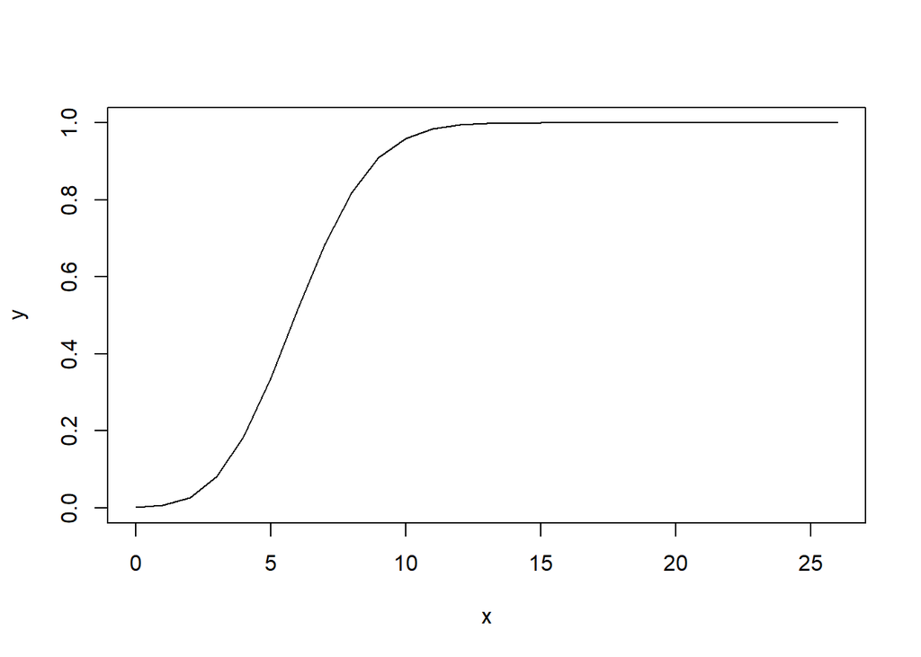

```r
x <- seq(0, 26, by = 1)
y <- pbinom(x, size = 26, prob = 0.25)
plot(x, y, type = 'l')
```